# Decade Analysis of Chinese Dramas

Understanding the industry and uncovering trends from productions released 2012-2022

Last updated: May 13, 2023

## Motivation

Chinese dramas consist of a wide variety of genres. Over time, the industry has changed in response to new regulations, modernized thinking, and rising stars. As I’ve watched dramas over the years and observed the evolution of the industry through hit shows, I’ve noticed some trends emerge. Through concrete data, I wish to showcase these trends and uncover interesting discoveries.

## Data Source

Information about each Chinese drama is scraped from the site [MyDramaList](https://mydramalist.com/), a database consisting of release information for Asian dramas and movies. I am interested in their list of [Chinese dramas](https://mydramalist.com/search?adv=titles&ty=68&co=2&st=3&so=top), specifically dramas released in 2012 to the end of 2022. To be considered, the drama also has to be rated by at least one user. The following fields are obtained:

- Page ID (unique, used to determine URL)
- Native title
- English title
- Year of release
- Episode count
- Genres
- Tags
- Cast members

There have been 3146 dramas released in the time period of interest. There have been 77971 assignments of people to projects, for 11913 unique personnel in the industry. The code used to scrape the data is included in the [GitHub repository.](https://github.com/kary5678/cdramas)

## Growth of the Industry

Over time, it seems that there are more and more hit shows per year - which may be attributed to a growth in the number of shows released. To determine if this is the case, the histogram below displays the number of dramas that have been released every year for the past decade.

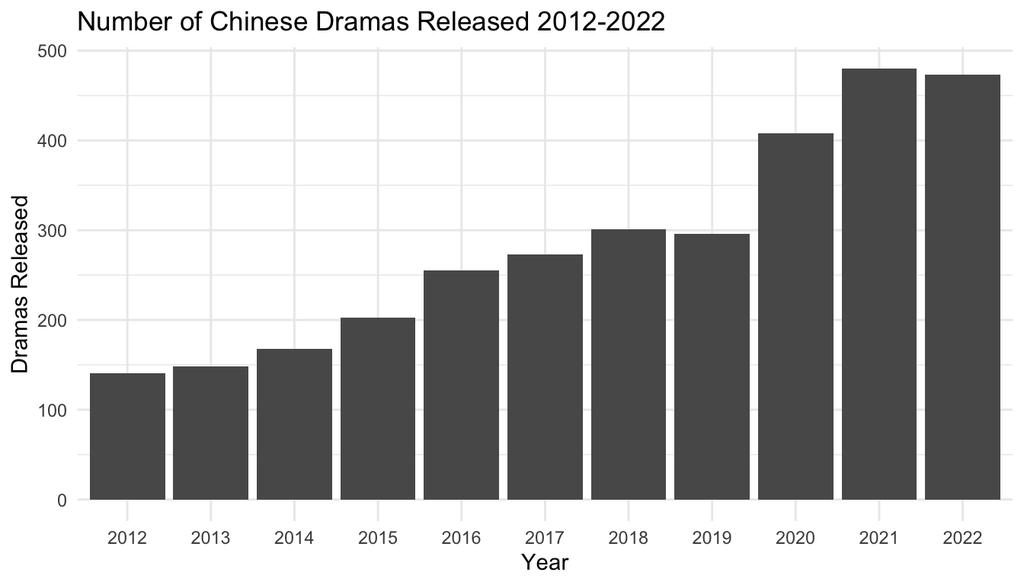

Over time, there has been a general increase in the number of dramas released per year. There is a notable spike from 2019 to 2020; the jump is over 100 dramas. Perhaps the increase can be attributed to the COVID-19 quarantine periods, as there is more demand for indoor entertainment.

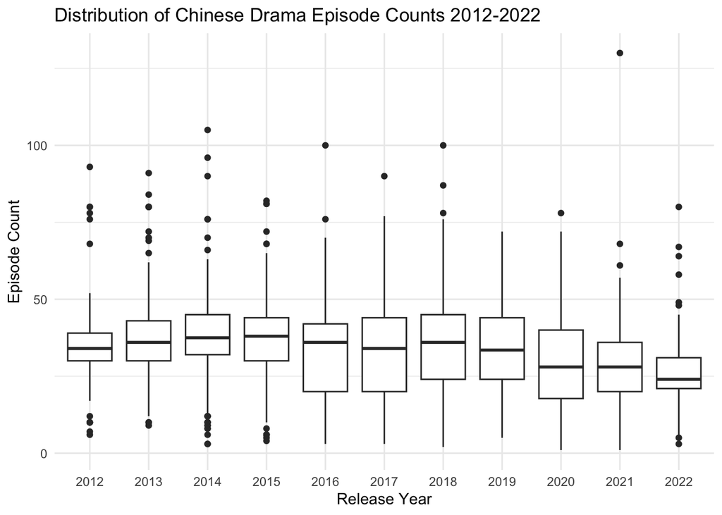

## Fun Facts

In this section, I will quickly satisfy some of the curiosities I’ve had with regards to the Chinese drama scene.

### The Longest Dramas

Many of my friends complain about the long episode count of Chinese dramas. What are the top 20 longest dramas by episode count?

|  | Title | Year | Episodes |
| --- | --- | --- | --- |
| 1 | [The Dreamlike Seal (如梦令)](https://mydramalist.com/681751-ru-meng-ling) | 2021 | 130 |
| 2 | [Because Love Is a Miracle (因为爱情有奇迹)](https://mydramalist.com/11706-because-love-is-a-miracle) | 2014 | 105 |
| 3 | [Qing Chun Peng You Quan (青春朋友圈)](https://mydramalist.com/46351-qing-chun-peng-you-quan) | 2016 | 100 |
| 4 | [A Family Has Children in the First Place (家有儿女初长成)](https://mydramalist.com/33825-a-family-has-children-in-the-first-place) | 2018 | 100 |
| 5 | [The Empress of China (武媚娘传奇)](https://mydramalist.com/9215-the-empress-of-china) | 2014 | 96 |
| 6 | [The Legend of Crazy Monk Season 3 (活佛济公)](https://mydramalist.com/12561-the-legend-of-crazy-monk-season-3) | 2012 | 93 |
| 7 | [A Happy Life (天天有喜)](https://mydramalist.com/7516-a-happy-life) | 2013 | 91 |
| 8 | [Legend of the Dragon Pearl: The Indistinguishable Road (龙珠传奇之无间道)](https://mydramalist.com/19928-legend-of-the-dragon-pearl-the-indistinguishable-road) | 2017 | 90 |
| 9 | [Brave Lover (加油愛人)](https://mydramalist.com/10291-brave-lover) | 2014 | 90 |
| 10 | [Ruyi’s Royal Love in the Palace (如懿传)](https://mydramalist.com/18756-ruyis-royal-love-in-the-palace) | 2018 | 87 |
| 11 | [Pearl (爱闪亮)](https://mydramalist.com/8615-pearl) | 2013 | 84 |
| 12 | [Tea Love (闪亮茗天)](https://mydramalist.com/14357-tea-love) | 2015 | 82 |
| 13 | [Legend of Mi Yue (芈月传)](https://mydramalist.com/11122-legend-of-miyue) | 2015 | 81 |
| 14 | [The Legend of Xiao Zhuang (大玉儿传奇)](https://mydramalist.com/11210-the-legend-of-xiao-zhuang) | 2015 | 81 |
| 15 | [Legend of Chu and Han (楚汉传奇)](https://mydramalist.com/3664-legend-of-chu-and-han) | 2012 | 80 |
| 16 | [Home, Sweet Home (我家有喜)](https://mydramalist.com/5813-home-sweet-home) | 2012 | 80 |
| 17 | [Love In Spring (爱在春天)](https://mydramalist.com/13615-love-in-spring) | 2013 | 80 |
| 18 | [Shining Days (璀璨人生)](https://mydramalist.com/7074-shining-days) | 2013 | 80 |
| 19 | [Because Love Is So Beautiful (因为爱情有多美)](https://mydramalist.com/13833-because-love-is-so-beautiful) | 2013 | 80 |
| 20 | [Dreams Can Come True (冬奥一家人)](https://mydramalist.com/697829-dong-ao-yi-jian-ren) | 2022 | 80 |

### Misclassified Dramas

One thing I disagree with the MDL site on is the classification of wuxia dramas. Per Wikipedia, wuxia “is a genre of Chinese fiction concerning the adventures of martial artists in ancient China.” Many titles are classified on MDL as wuxias when in reality they are xianxias or xuanhuans with fantasy elements. Which dramas aren’t actually wuxias?

|  | Title | Year | Episodes |
| --- | --- | --- | --- |
| 1 | [Love Between Fairy and Devil (苍兰诀)](https://mydramalist.com/53117-cang-lan-jue) | 2022 | 36 |
| 2 | [The Blood of Youth (少年歌行)](https://mydramalist.com/683119-shao-nian-ge-xing) | 2022 | 40 |
| 3 | [Who Rules the World (且试天下)](https://mydramalist.com/54851-try-the-world) | 2022 | 40 |
| 4 | [The Blue Whisper: Part 2 (恰似故人归)](https://mydramalist.com/688563-the-blue-whisper-part-2) | 2022 | 20 |
| 5 | [The Blue Whisper: Part 1 (与君初相识)](https://mydramalist.com/64085-yu-jiao-ji) | 2022 | 22 |
| 6 | [Immortal Samsara: Part 1 (沉香如屑)](https://mydramalist.com/72025-chen-xiang-ru-xie) | 2022 | 38 |
| 7 | [Immortal Samsara: Part 2 (沉香重华)](https://mydramalist.com/733265-immortal-samsara-part-2) | 2022 | 21 |
| 8 | [Song of the Moon (月歌行)](https://mydramalist.com/66261-ben-yue) | 2022 | 40 |
| 9 | [Ms. Cupid in Love (姻缘大人请留步)](https://mydramalist.com/78641-yin-yuan-da-ren-qing-liu-bu) | 2022 | 24 |
| 10 | [Thousand Years for You (请君)](https://mydramalist.com/706617-qing-jun-ci-jiao) | 2022 | 36 |
| 11 | [Legend of Yunze Season 2 (云泽传2)](https://mydramalist.com/726101-legend-of-yunze-2) | 2022 | 15 |
| 12 | [The Origin of Eternity (三生缘起是清欢)](https://mydramalist.com/743705-san-sheng-yuan-qi-shi-qing-huan) | 2022 | 23 |
| 13 | [Seal of Love (浮生印)](https://mydramalist.com/719955-fu-sheng-yin) | 2022 | 24 |
| 14 | [Ru Hua Ru Tu (如花如荼)](https://mydramalist.com/736037-ru-hua-ru-tu) | 2022 | 20 |
| 15 | [Is Xian Zun Whitewashed Today? (仙尊，今天洗白了吗)](https://mydramalist.com/718659-is-xianzun-whitewashed-today) | 2022 | 25 |
| 16 | [Mirror: A Tale of Twin Cities (镜·双城)](https://mydramalist.com/33697-mirror-twin-cities) | 2022 | 43 |
| 17 | [Scent of Love (闻香榭)](https://mydramalist.com/711045-wen-xiang-xie) | 2022 | 14 |
| 18 | [Huang Shu Da Ren Jie Yuan Ba (皇叔大人结缘吧)](https://mydramalist.com/725435-huang-shu-da-ren-jie-yuan-ba) | 2022 | 24 |
| 19 | [Ting Hua Ling (听花令)](https://mydramalist.com/740377-ting-hua-ling) | 2022 | 30 |
| 20 | [There’s a Genie Next Door (隔壁有只桃花妖)](https://mydramalist.com/63685-there-s-a-genie-next-door) | 2022 | 26 |
| 21 | [Sword Snow Stride (雪中悍刀行)](https://mydramalist.com/59487-sword-snow-stride) | 2021 | 38 |
| 22 | [Ancient Love Poetry (千古玦尘)](https://mydramalist.com/59327-the-legend-of-gu-and-jue) | 2021 | 49 |
| 23 | [Word of Honor (山河令)](https://mydramalist.com/59021-tian-ya-ke) | 2021 | 36 |
| 24 | [Douluo Continent (斗罗大陆)](https://mydramalist.com/33701-douluo-continent) | 2021 | 40 |
| 25 | [Novoland: Pearl Eclipse (斛珠夫人)](https://mydramalist.com/31998-novoland-pearl-eclipse) | 2021 | 48 |
| 26 | [No Boundary Season 2 (玉昭令第二季)](https://mydramalist.com/700057-no-boundary-season-2) | 2021 | 20 |
| 27 | [No Boundary (玉昭令)](https://mydramalist.com/51985-yu-zhao-ling) | 2021 | 32 |
| 28 | [My Dear Brothers (亲爱的吾兄)](https://mydramalist.com/64063-qin-ai-de-wu-xiong) | 2021 | 35 |
| 29 | [Miss the Dragon (遇龙)](https://mydramalist.com/53591-yu-long) | 2021 | 36 |
| 30 | [Legend of Yunze (云泽传)](https://mydramalist.com/708663-legend-of-yunze) | 2021 | 12 |

[output cut: 112 more lines]

## The Love of “Love”

Something that bothers me is the use of the word “love” in most titles, when the native title has nothing to do with the word.

### Top Words Used

From the scraped data, there are 10943 words when all English titles are broken down, and 16728 characters across all native titles. Let’s see what the most common words/characters are across all titles.

Top 20 Words Used in Titles (With Counts)

|  | 1 | 2 | 3 | 4 | 5 | 6 | 7 | 8 | 9 | 10 | 11 | 12 | 13 | 14 | 15 | 16 | 17 | 18 | 19 | 20 |
| --- | --- | --- | --- | --- | --- | --- | --- | --- | --- | --- | --- | --- | --- | --- | --- | --- | --- | --- | --- | --- |
| English: | the (767) | of (407) | love (386) | my (213) | in (175) | 2 (163) | you (163) | season (161) | a (136) | to (116) | and (105) | is (76) | legend (67) | with (61) | me (56) | i (50) | life (50) | time (50) | youth (48) | for (47) |
| Native: | 的 (542) | 我 (328) | 爱 (266) | 你 (228) | 之 (184) | 人 (184) | 一 (161) | 大 (151) | 天 (142) | 不 (135) | 小 (129) | 生 (128) | 女 (126) | 第 (112) | 季 (105) | 恋 (104) | 是 (102) | 花 (101) | 上 (95) | 子 (92) |

Excluding common particles such as “the” and “of”, which occur the most often to no surprise, there are 386 occurrences of the word “love”. To put this in perspective, there are 3146 dramas. Furthermore, not all 386 of these dramas actually use the word “love” in the native title.

### Love Introduced in Translation

How many of these titles with the word “love” in the English title actually use the word love (or a similar term) in the native title?

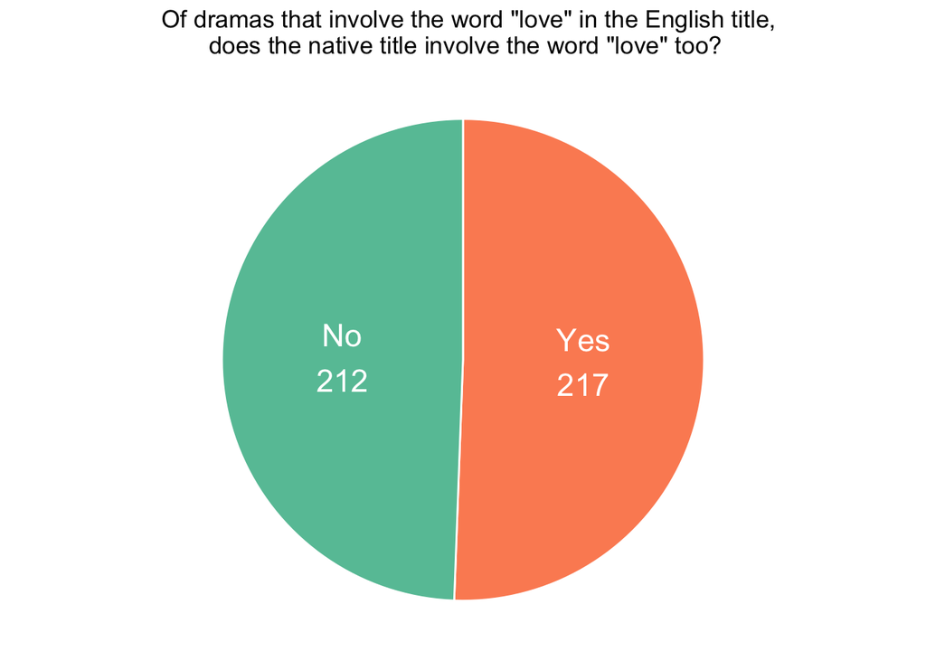

### Where is Love?

Not only is the word “love” in many localized titles, there is also a pattern to its location in titles. For example, some hit dramas’ titles include Ashes of Love, Eternal Love, and Intense Love. It seems that the localization is very formulaic - but is this actually the case? Or is there an even spread in the location of the word “love”?

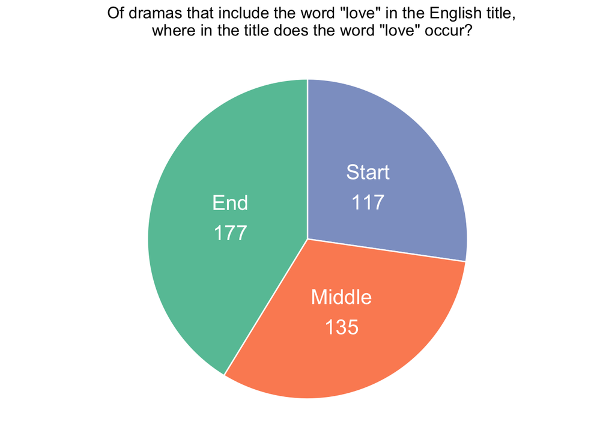

Most of the English titles contain the word “love” at the very end of the title, as I have observed. However, the spread in the location of the word is arguably more even than I thought it was initially.

## Examination of Industry Personnel

### Hard Working Cast Members

People Who Have Worked on the Most Dramas

|  | Person | Dramas |
| --- | --- | --- |
| 1 | [Gong Yu](https://mydramalist.com/people/52025-gong-yu) | 236 |
| 2 | [Xie Ying](https://mydramalist.com/people/52311-xie-ying) | 111 |
| 3 | [Han Zhi Jie](https://mydramalist.com/people/46477-han-zhi-jie) | 94 |
| 4 | [Li Hong Lei](https://mydramalist.com/people/44071-li-hong-lei) | 84 |
| 5 | [Shen Bao Ping](https://mydramalist.com/people/5189-shen-bao-ping) | 67 |
| 6 | [Ren Luo Min](https://mydramalist.com/people/13282-ren-luo-min) | 67 |
| 7 | [Leng Hai Ming](https://mydramalist.com/people/14328-leng-hai-ming) | 66 |
| 8 | [Tan Xuan](https://mydramalist.com/people/56309-tan-xuan) | 63 |
| 9 | [Tan Kai](https://mydramalist.com/people/6490-tan-kevin) | 62 |
| 10 | [Dai Ying](https://mydramalist.com/people/51837-dai-ying) | 62 |
| 11 | [Zhang Lei](https://mydramalist.com/people/17225-lei-zhang) | 61 |
| 12 | [Yue Yao Li](https://mydramalist.com/people/7069-yue-yao-li) | 60 |
| 13 | [Wang Gang](https://mydramalist.com/people/15158-wang-gang) | 59 |
| 14 | [Li Bin](https://mydramalist.com/people/44279-li-bin) | 58 |
| 15 | [Fang Xiao Li](https://mydramalist.com/people/25315-fang-xiao-li) | 58 |
| 16 | [Lily Wang](https://mydramalist.com/people/14720-wang-lily) | 57 |
| 17 | [Zhang Gong](https://mydramalist.com/people/14327-zhang-gong) | 57 |
| 18 | [Lu Zheng](https://mydramalist.com/people/12990-lu-sen-bao) | 56 |
| 19 | [Chen Xiao](https://mydramalist.com/people/54037-chen-xiao) | 54 |
| 20 | [Zhao Wen Ming](https://mydramalist.com/people/39817-zhao-wen-ming) | 54 |

#### Most Hard Working Since 2018

People Who Have Worked on the Most Dramas Since 2018

|  | Person | Dramas |
| --- | --- | --- |
| 1 | [Li Hong Lei](https://mydramalist.com/people/44071-li-hong-lei) | 63 |
| 2 | [Li Bin](https://mydramalist.com/people/44279-li-bin) | 52 |
| 3 | [Ren Luo Min](https://mydramalist.com/people/13282-ren-luo-min) | 50 |
| 4 | [Zhang Gong](https://mydramalist.com/people/14327-zhang-gong) | 48 |
| 5 | [Lu Zheng](https://mydramalist.com/people/12990-lu-sen-bao) | 45 |
| 6 | [Jing Lu](https://mydramalist.com/people/36865-jing-lu) | 44 |
| 7 | [Zhao Wen Ming](https://mydramalist.com/people/39817-zhao-wen-ming) | 43 |
| 8 | [Zhang Lei](https://mydramalist.com/people/17225-lei-zhang) | 42 |
| 9 | [Wang Jin Song](https://mydramalist.com/people/13278-wang-jin-song) | 41 |
| 10 | [Tan Kai](https://mydramalist.com/people/6490-tan-kevin) | 40 |
| 11 | [Zhang Da Bao](https://mydramalist.com/people/50879-zhang-da-bao) | 40 |
| 12 | [Qu Gang](https://mydramalist.com/people/23078-qu-gang) | 39 |
| 13 | [Leng Hai Ming](https://mydramalist.com/people/14328-leng-hai-ming) | 39 |
| 14 | [Bao Ma](https://mydramalist.com/people/59887-bao-ma) | 38 |
| 15 | [Fang Xiao Li](https://mydramalist.com/people/25315-fang-xiao-li) | 36 |
| 16 | [Tian Miao](https://mydramalist.com/people/23194-tian-miao) | 36 |
| 17 | [Yan Jing Yao](https://mydramalist.com/people/18724-yan-jing-yao) | 36 |
| 18 | [Dong Li Wu You](https://mydramalist.com/people/18735-dong-li-wu-you) | 34 |
| 19 | [Wang Bin](https://mydramalist.com/people/58729-wang-bin) | 33 |
| 20 | [Chen Xu Ming](https://mydramalist.com/people/38199-chen-xu-ming) | 33 |

### Most Romantic People

People Who Have Been Involved in the Most Romance Dramas

|  | Person | Dramas |
| --- | --- | --- |
| 1 | [Leng Hai Ming](https://mydramalist.com/people/14328-leng-hai-ming) | 54 |
| 2 | [Li Hong Lei](https://mydramalist.com/people/44071-li-hong-lei) | 48 |
| 3 | [Yue Yao Li](https://mydramalist.com/people/7069-yue-yao-li) | 45 |
| 4 | [Rong Rong](https://mydramalist.com/people/3029-rong-rong) | 44 |
| 5 | [Lu Zheng](https://mydramalist.com/people/12990-lu-sen-bao) | 44 |
| 6 | [Zhang Lei](https://mydramalist.com/people/17225-lei-zhang) | 43 |
| 7 | [Lily Wang](https://mydramalist.com/people/14720-wang-lily) | 43 |
| 8 | [Tian Miao](https://mydramalist.com/people/23194-tian-miao) | 42 |
| 9 | [Zhang Gong](https://mydramalist.com/people/14327-zhang-gong) | 42 |
| 10 | [Shen Bao Ping](https://mydramalist.com/people/5189-shen-bao-ping) | 41 |
| 11 | [Chen Xu Ming](https://mydramalist.com/people/38199-chen-xu-ming) | 41 |
| 12 | [Fang Xiao Li](https://mydramalist.com/people/25315-fang-xiao-li) | 41 |
| 13 | [Zong Feng Yan](https://mydramalist.com/people/7409-zong-feng-yan) | 40 |
| 14 | [Jing Lu](https://mydramalist.com/people/36865-jing-lu) | 40 |
| 15 | [Zhang Da Bao](https://mydramalist.com/people/50879-zhang-da-bao) | 39 |
| 16 | [Cai Gang](https://mydramalist.com/people/15144-cai-gang) | 39 |
| 17 | [Ren Luo Min](https://mydramalist.com/people/13282-ren-luo-min) | 39 |
| 18 | [Tan Kai](https://mydramalist.com/people/6490-tan-kevin) | 38 |
| 19 | [Wang Bin](https://mydramalist.com/people/58729-wang-bin) | 38 |
| 20 | [Qu Gang](https://mydramalist.com/people/23078-qu-gang) | 38 |

### Most Involved Dramas

Dramas That Involve the Most People

|  | Drama | Personnel |
| --- | --- | --- |
| 1 | [Faith Makes Great (理想照耀中国)](https://mydramalist.com/685281-faith-makes-great) | 271 |
| 2 | [Serenade of Peaceful Joy (清平乐)](https://mydramalist.com/31928-held-in-the-lonely-castle) | 154 |
| 3 | [Court Lady (骊歌行)](https://mydramalist.com/33630-the-glorious-tang-stratagem) | 148 |
| 4 | [Who Rules the World (且试天下)](https://mydramalist.com/54851-try-the-world) | 147 |
| 5 | [Ruyi’s Royal Love in the Palace (如懿传)](https://mydramalist.com/18756-ruyis-royal-love-in-the-palace) | 141 |
| 6 | [With You (在一起)](https://mydramalist.com/58585-together) | 140 |
| 7 | [The Story of Ming Lan (知否知否应是绿肥红瘦)](https://mydramalist.com/23911-the-story-of-ming-lan) | 140 |
| 8 | [The Longest Day in Chang’an (长安十二时辰)](https://mydramalist.com/28435-the-longest-day-in-chang-an) | 139 |
| 9 | [Dreams and Glory (光荣与梦想)](https://mydramalist.com/63511-dreams-and-glory) | 136 |
| 10 | [Strange Tales of Tang Dynasty (唐朝诡事录)](https://mydramalist.com/78279-horror-stories-of-tang-dynasty) | 124 |
| 11 | [Thank You, Doctor (谢谢你医生)](https://mydramalist.com/50127-thank-you-doctor) | 124 |
| 12 | [Nirvana in Fire (琅琊榜)](https://mydramalist.com/9025-nirvana-in-fire) | 122 |
| 13 | [Miss S (旗袍美探)](https://mydramalist.com/34655-miss-s) | 120 |
| 14 | [Winter Begonia (鬓边不是海棠红)](https://mydramalist.com/31618-winter-begonia) | 118 |
| 15 | [Word of Honor (山河令)](https://mydramalist.com/59021-tian-ya-ke) | 117 |
| 16 | [Qin Dynasty Epic (大秦赋之东出)](https://mydramalist.com/36307-the-qin-empire-4) | 115 |
| 17 | [The Legend of Xiao Chuo (燕云台)](https://mydramalist.com/34637-the-legend-of-xiao-chuo) | 112 |
| 18 | [The Blood of Youth (少年歌行)](https://mydramalist.com/683119-shao-nian-ge-xing) | 111 |
| 19 | [Song of Youth (玉楼春)](https://mydramalist.com/51217-yu-lou-chun) | 111 |
| 20 | [Eastern Battlefield (东方战场)](https://mydramalist.com/24840-eastern-battlefield) | 110 |

## Genre Breakdown

### Most Common Genres

There are 32 unique genres across the dramas analyzed, although the dramas can be multiple genres. What are the most common genres?

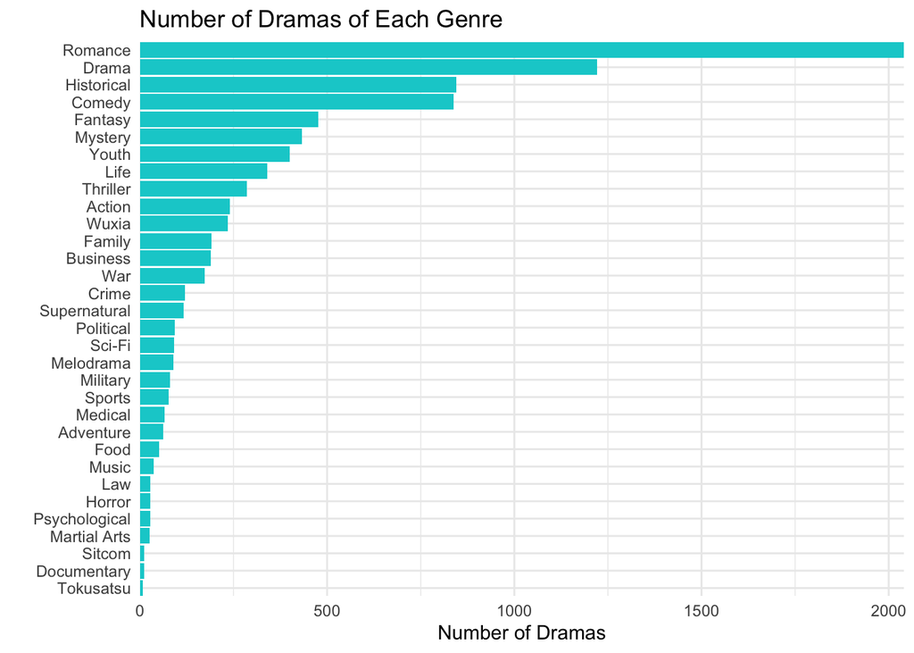

### Most Common Tags

Next, what are some popular themes or tropes? This can be examined by analyzing drama tags submitted by MDL users. There are 1800+ unique tags across the dramas analyzed, so the focus will be on the top 25 most common tags.

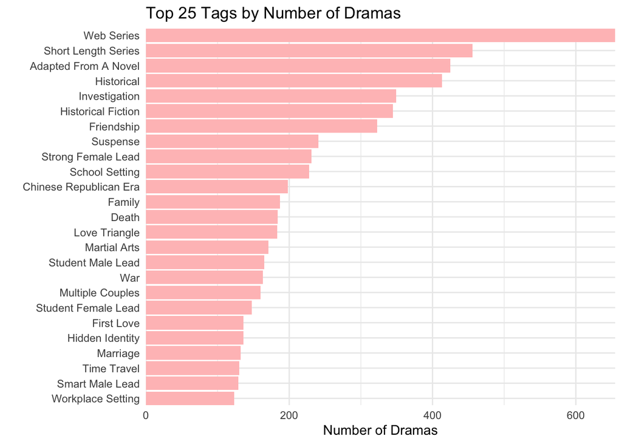